# limiares

#### Allegro

0.1 [1] “

"

#### Evolução dos desenvolvedores ao longo do tempo

( janela 24 semanas, iteracao de 4 semanas) [1] “

"

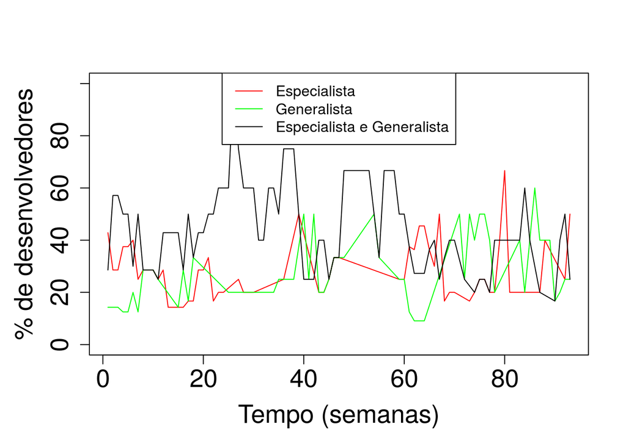

|  | esp | gen | espgen |
| --- | --- | --- | --- |
| twosided | 0.8007013 | 0.0014012 | 0.03694 |
| greater | 0.4003507 | 0.0007006 | 0.98153 |
| less | 0.5996493 | 0.9992994 | 0.01847 |

#### Allegro

0.2 [1] “

"

#### Evolução dos desenvolvedores ao longo do tempo

( janela 24 semanas, iteracao de 4 semanas) [1] “

"

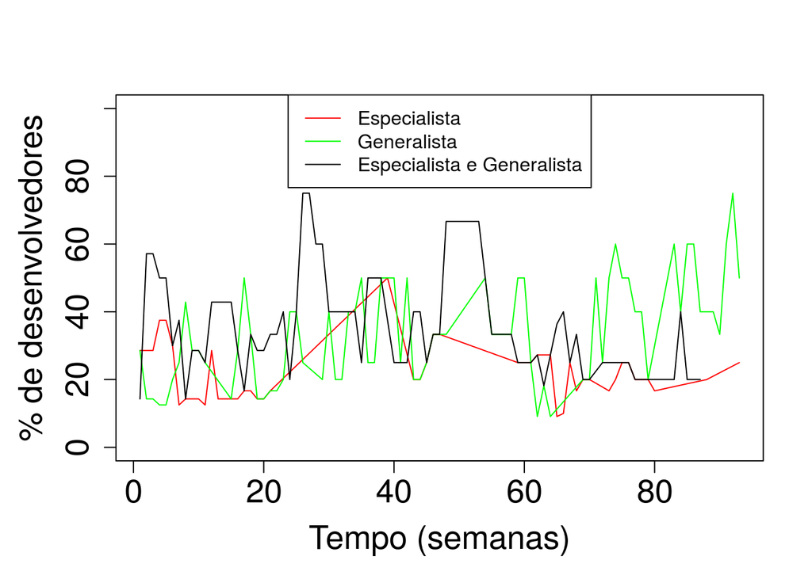

|  | esp | gen | espgen |
| --- | --- | --- | --- |
| twosided | 0.9028886 | 0.0000051 | 0.0025873 |
| greater | 0.4514443 | 0.0000026 | 0.9987064 |
| less | 0.5485557 | 0.9999974 | 0.0012936 |

#### Allegro

0.3 [1] “

"

#### Evolução dos desenvolvedores ao longo do tempo

( janela 24 semanas, iteracao de 4 semanas) [1] “

"

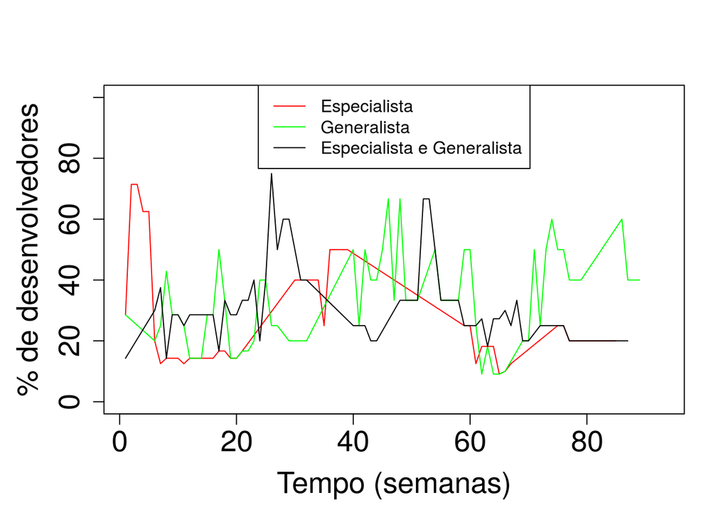

|  | esp | gen | espgen |
| --- | --- | --- | --- |
| twosided | 0.9618704 | 0.0067110 | 0.1129165 |
| greater | 0.5190648 | 0.0033555 | 0.9435417 |
| less | 0.4809352 | 0.9966445 | 0.0564583 |

#### Allegro

0.4 [1] “

"

#### Evolução dos desenvolvedores ao longo do tempo

( janela 24 semanas, iteracao de 4 semanas) [1] “

"

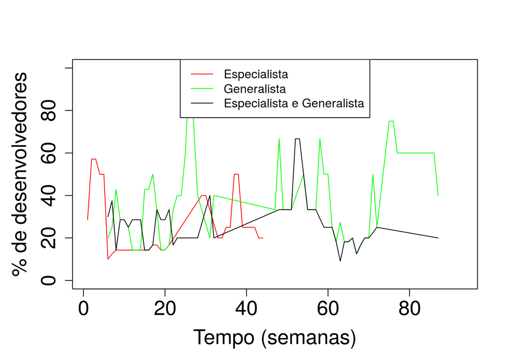

|  | esp | gen | espgen |
| --- | --- | --- | --- |
| twosided | 0.2047001 | 0.1842107 | 0.2699092 |
| greater | 0.1023501 | 0.0921054 | 0.8650454 |
| less | 0.8976499 | 0.9078946 | 0.1349546 |

#### Allegro

0.5 [1] “

"

#### Evolução dos desenvolvedores ao longo do tempo

( janela 24 semanas, iteracao de 4 semanas) [1] “

"

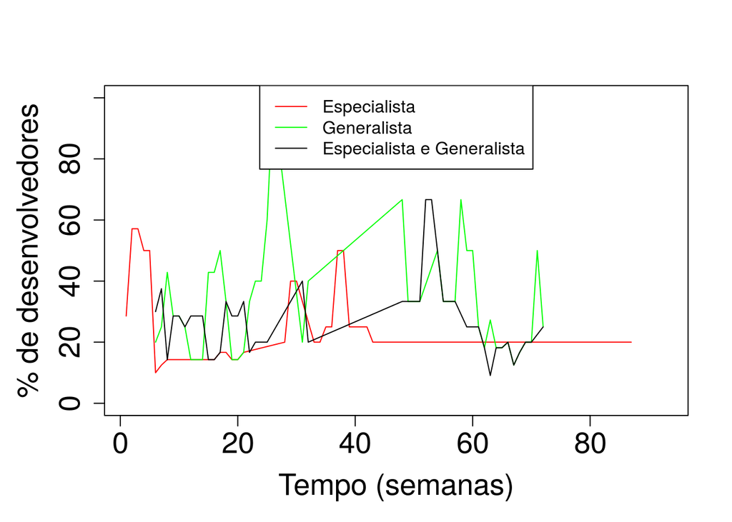

|  | esp | gen | espgen |
| --- | --- | --- | --- |
| twosided | 0.1615725 | 0.8488818 | 0.2994616 |
| greater | 0.0807862 | 0.5755591 | 0.8502692 |
| less | 0.9192138 | 0.4244409 | 0.1497308 |

#### SDL

0.1 [1] “

"

#### Evolução dos desenvolvedores ao longo do tempo

( janela 24 semanas, iteracao de 4 semanas) [1] “

"

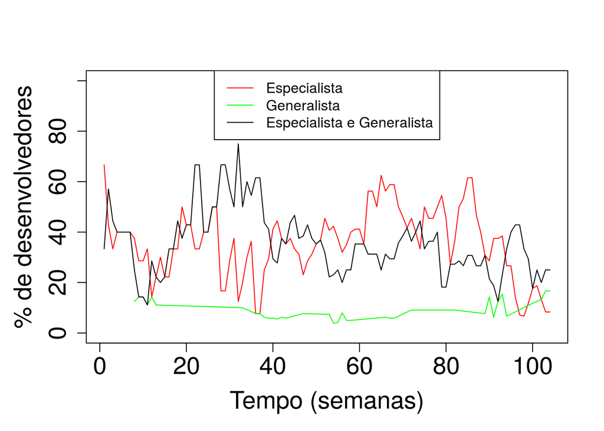

|  | esp | gen | espgen |
| --- | --- | --- | --- |
| twosided | 0.6710770 | 0.1572583 | 0.0000450 |
| greater | 0.3355385 | 0.0786291 | 0.9999775 |
| less | 0.6644615 | 0.9213709 | 0.0000225 |

#### SDL

0.2 [1] “

"

#### Evolução dos desenvolvedores ao longo do tempo

( janela 24 semanas, iteracao de 4 semanas) [1] “

"

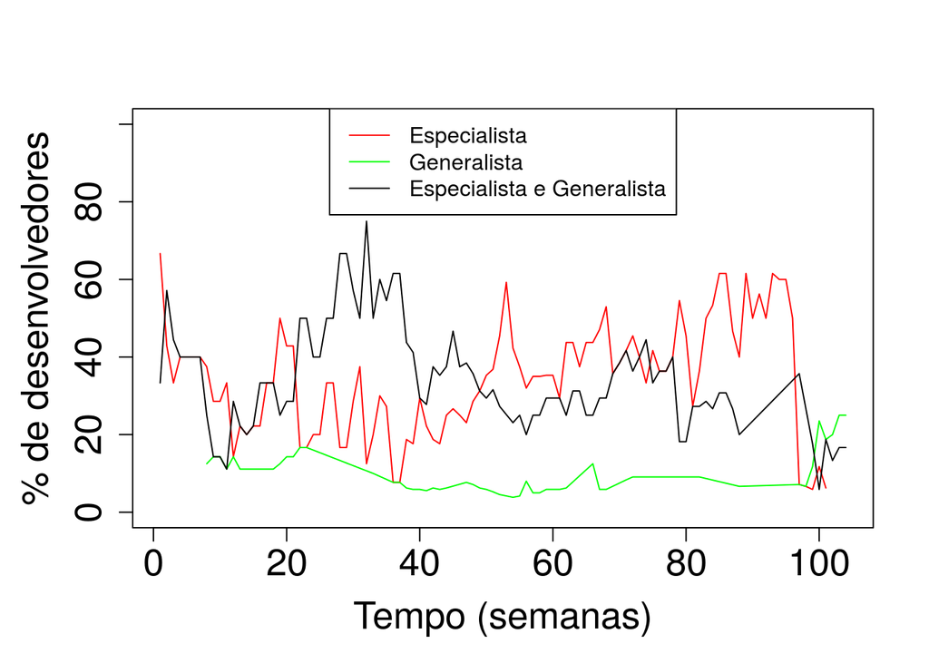

|  | esp | gen | espgen |
| --- | --- | --- | --- |
| twosided | 0.0001035 | 0.8155451 | 0.0002581 |
| greater | 0.0000518 | 0.5922274 | 0.9998710 |
| less | 0.9999482 | 0.4077726 | 0.0001290 |

#### SDL

0.3 [1] “

"

#### Evolução dos desenvolvedores ao longo do tempo

( janela 24 semanas, iteracao de 4 semanas) [1] “

"

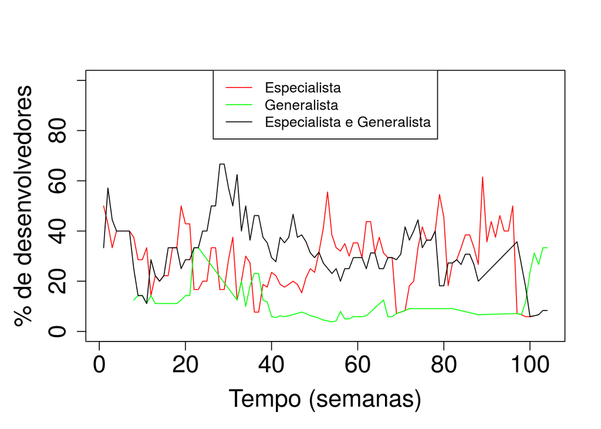

|  | esp | gen | espgen |
| --- | --- | --- | --- |
| twosided | 0.6637268 | 0.3372953 | 0.0001802 |
| greater | 0.3318634 | 0.8313524 | 0.9999099 |
| less | 0.6681366 | 0.1686476 | 0.0000901 |

#### SDL

0.4 [1] “

"

#### Evolução dos desenvolvedores ao longo do tempo

( janela 24 semanas, iteracao de 4 semanas) [1] “

"

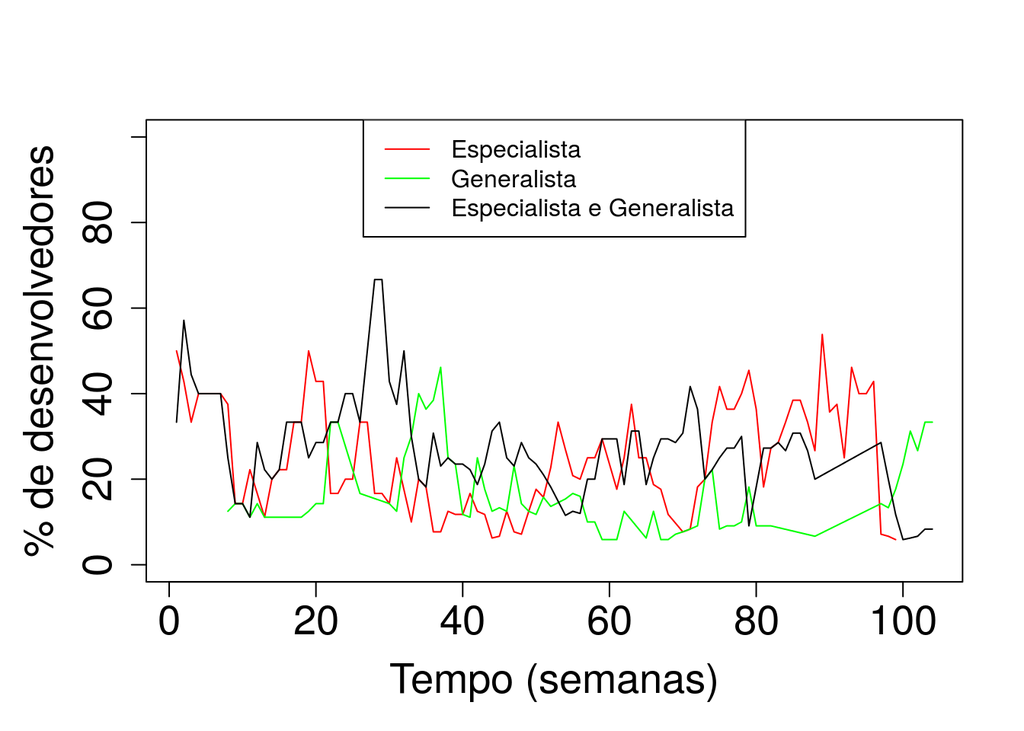

|  | esp | gen | espgen |
| --- | --- | --- | --- |
| twosided | 0.3713867 | 0.1078052 | 0.0000728 |
| greater | 0.1856934 | 0.9460974 | 0.9999636 |
| less | 0.8143066 | 0.0539026 | 0.0000364 |

#### SDL

0.5 [1] “

"

#### Evolução dos desenvolvedores ao longo do tempo

( janela 24 semanas, iteracao de 4 semanas) [1] “

"

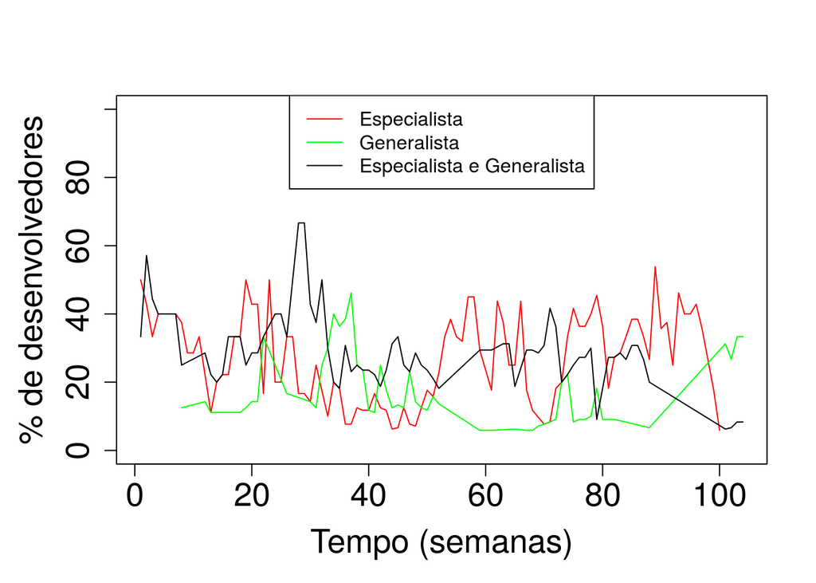

|  | esp | gen | espgen |
| --- | --- | --- | --- |
| twosided | 0.5242762 | 0.0706087 | 0.0000486 |
| greater | 0.2621381 | 0.9646957 | 0.9999757 |
| less | 0.7378619 | 0.0353043 | 0.0000243 |

#### SFML

0.1 [1] “

"

#### Evolução dos desenvolvedores ao longo do tempo

( janela 24 semanas, iteracao de 4 semanas) [1] “

"

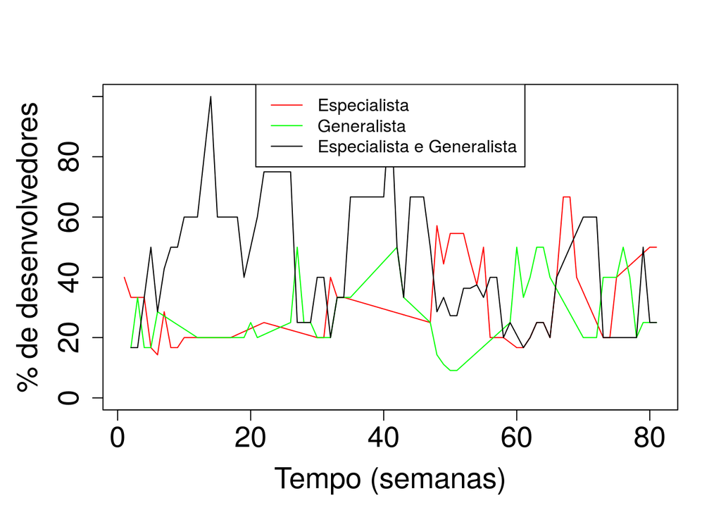

|  | esp | gen | espgen |
| --- | --- | --- | --- |
| twosided | 0.0438986 | 0.0167488 | 0.004512 |
| greater | 0.0219493 | 0.0083744 | 0.997744 |
| less | 0.9780507 | 0.9916256 | 0.002256 |

#### SFML

0.2 [1] “

"

#### Evolução dos desenvolvedores ao longo do tempo

( janela 24 semanas, iteracao de 4 semanas) [1] “

"

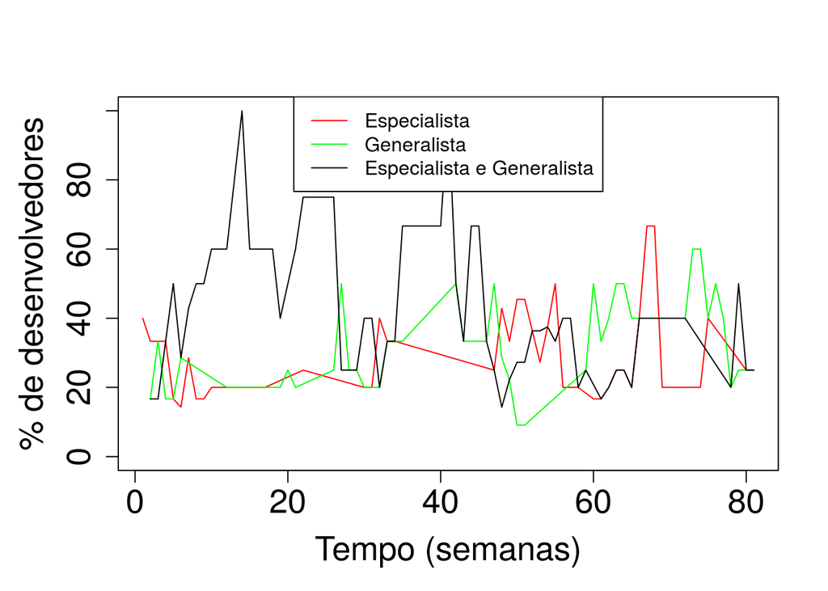

|  | esp | gen | espgen |
| --- | --- | --- | --- |
| twosided | 0.2731359 | 0.0002491 | 0.0044591 |
| greater | 0.1365679 | 0.0001246 | 0.9977705 |
| less | 0.8634321 | 0.9998754 | 0.0022295 |

#### SFML

0.3 [1] “

"

#### Evolução dos desenvolvedores ao longo do tempo

( janela 24 semanas, iteracao de 4 semanas) [1] “

"

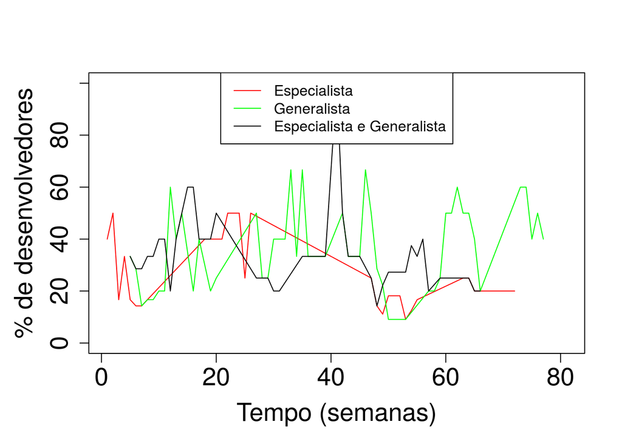

|  | esp | gen | espgen |
| --- | --- | --- | --- |
| twosided | 0.3283009 | 0.0806895 | 0.0140847 |
| greater | 0.8358495 | 0.0403447 | 0.9929577 |
| less | 0.1641505 | 0.9596553 | 0.0070423 |

#### SFML

0.4 [1] “

"

#### Evolução dos desenvolvedores ao longo do tempo

( janela 24 semanas, iteracao de 4 semanas) [1] “

"

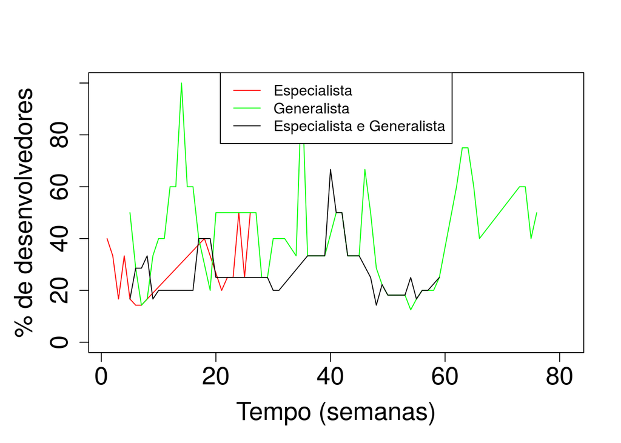

|  | esp | gen | espgen |
| --- | --- | --- | --- |
| twosided | 0.3154889 | 0.6606883 | 0.6028078 |
| greater | 0.1577444 | 0.6696558 | 0.6985961 |
| less | 0.8422556 | 0.3303442 | 0.3014039 |

#### SFML

0.5 [1] “

"

#### Evolução dos desenvolvedores ao longo do tempo

( janela 24 semanas, iteracao de 4 semanas) [1] “

"

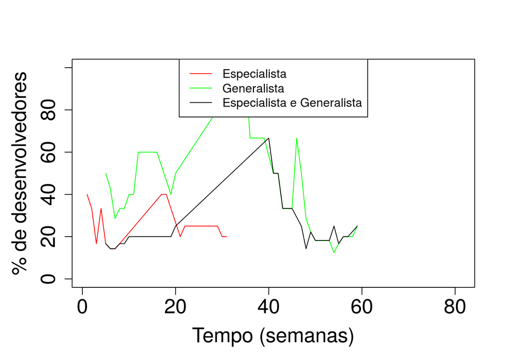

|  | esp | gen | espgen |
| --- | --- | --- | --- |
| twosided | 0.7632393 | 0.0010494 | 0.2109217 |
| greater | 0.6183803 | 0.9994753 | 0.1054608 |
| less | 0.3816197 | 0.0005247 | 0.8945392 |

#### Coco2dx

0.1 [1] “

"

#### Evolução dos desenvolvedores ao longo do tempo

( janela 24 semanas, iteracao de 4 semanas) [1] “

"

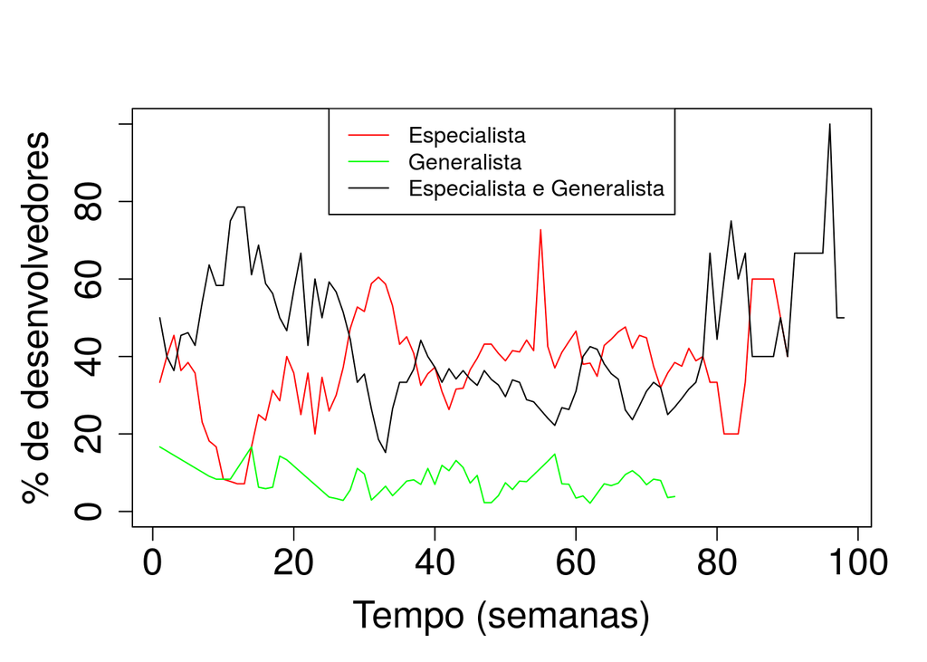

|  | esp | gen | espgen |
| --- | --- | --- | --- |
| twosided | 0.0002751 | 0.2953573 | 0.1900099 |
| greater | 0.0001375 | 0.8523214 | 0.9049950 |
| less | 0.9998625 | 0.1476786 | 0.0950050 |

#### Coco2dx

0.2 [1] “

"

#### Evolução dos desenvolvedores ao longo do tempo

( janela 24 semanas, iteracao de 4 semanas) [1] “

"

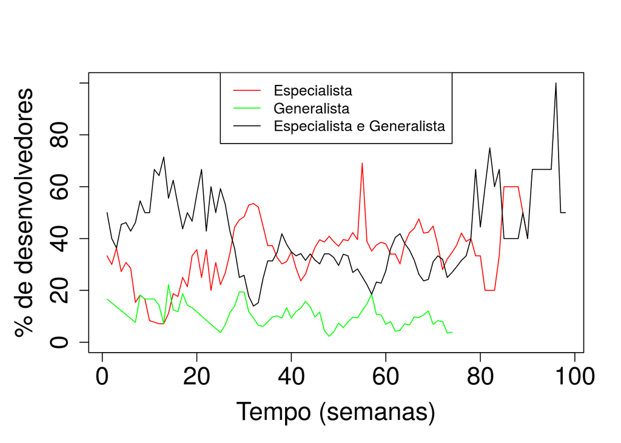

|  | esp | gen | espgen |
| --- | --- | --- | --- |
| twosided | 0.0000008 | 0.0000922 | 0.6667769 |
| greater | 0.0000004 | 0.9999539 | 0.6666115 |
| less | 0.9999996 | 0.0000461 | 0.3333885 |

#### Coco2dx

0.3 [1] “

"

#### Evolução dos desenvolvedores ao longo do tempo

( janela 24 semanas, iteracao de 4 semanas) [1] “

"

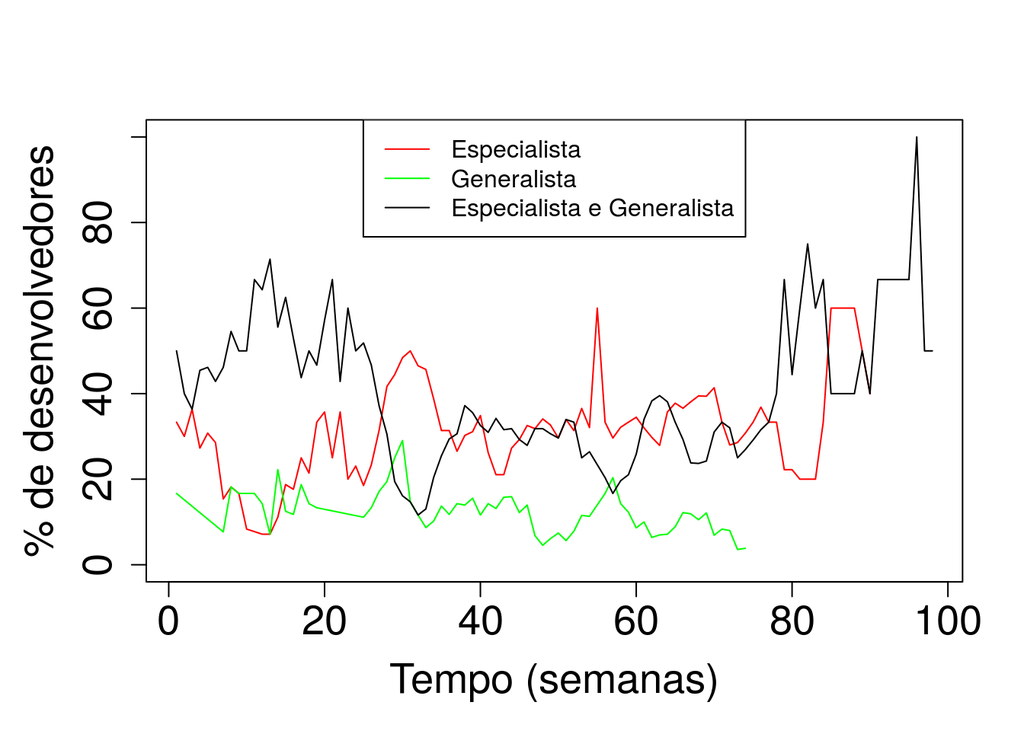

|  | esp | gen | espgen |
| --- | --- | --- | --- |
| twosided | 0.0000273 | 0.0000119 | 0.8198295 |
| greater | 0.0000136 | 0.9999941 | 0.4099148 |
| less | 0.9999864 | 0.0000059 | 0.5900852 |

#### Coco2dx

0.4 [1] “

"

#### Evolução dos desenvolvedores ao longo do tempo

( janela 24 semanas, iteracao de 4 semanas) [1] “

"

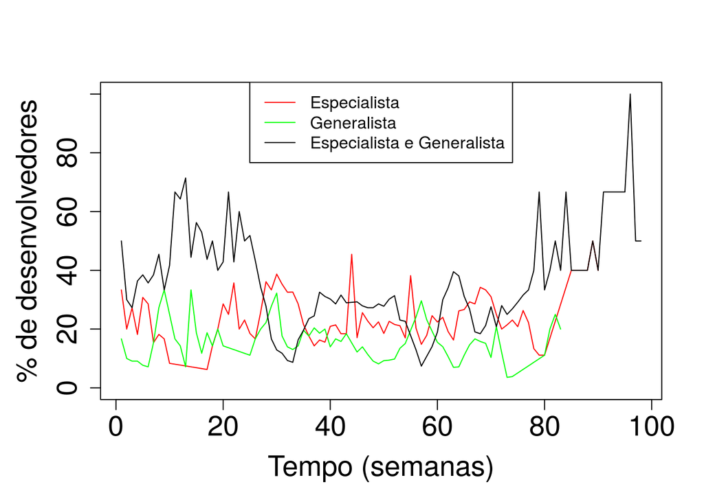

|  | esp | gen | espgen |
| --- | --- | --- | --- |
| twosided | 0.0655792 | 0.3305739 | 0.4081623 |
| greater | 0.0327896 | 0.8347131 | 0.2040811 |
| less | 0.9672104 | 0.1652869 | 0.7959189 |

#### Coco2dx

0.5 [1] “

"

#### Evolução dos desenvolvedores ao longo do tempo

( janela 24 semanas, iteracao de 4 semanas) [1] “

"

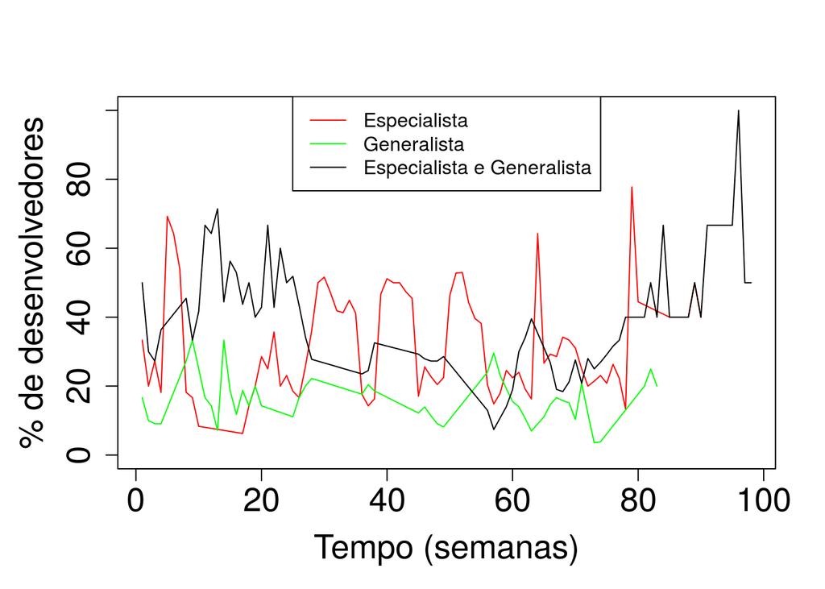

|  | esp | gen | espgen |
| --- | --- | --- | --- |
| twosided | 0.3561753 | 0.4612155 | 0.5995143 |
| greater | 0.1780876 | 0.7693923 | 0.2997572 |
| less | 0.8219124 | 0.2306077 | 0.7002428 |